# miR-375 KO (baseline)

Milo: Differential abundance analysis (test)

## Sample description

This is the single cell RNAseq data of two 375KO mice and two WT mice (generated by 10X Genomics Chromium platform - 3’ V2 kit). Samples were jejunal crypts isolated from sex and age matched 375KO and WT mice (male; 12m old; chow diet condition). Set 1 contained one 375KO and one WT mice processed in April 2019. Set 2 contained one 375KO and one WT mice processed in October 2019.

## Load required libraries

```r
library(stringr)
library(Seurat)
library(tidyverse)

library(BiocParallel)
library(glmGamPoi)

library(scater)
library(miloR)
```

## Milo (package miloR)

Tool Milo was developed by [Dann et al., Nature Biotechnoloty (2021)](https://www.nature.com/articles/s41587-021-01033-z). It represents a scalable statistical framework that performs differential abundance testing by assigning cells to partially overlapping neighborhoods on a k-nearest neighbor graph. It does not require prior knowledge of cell type of your scRNA-seq. I basically followed this [vignette](https://bioconductor.riken.jp/packages/devel/bioc/vignettes/miloR/inst/doc/milo_demo.html) to test this method with my dataset.

## Data preparation

The current version of miloR has issues directly working on a Seurat object with pre-calculated clustering. If one wants to present miloR result by overlay it in a UMAP, he/shes needs to repeat Seurat clustering step.

## Make Milo object

Load the Seurat object with pre-calculated clusteirng info. Here I directly load Milo object I made previoulsy.

```r
# load Seurat object (done with doublet removal, filtering and clustering)
proj_name <- "375KO-12m"
seurat_obj <- readRDS("/home/yah6/2022_04_375KO-12m_reanalysis/375KO-12mclusteredName_seurat-obj.rds")
```

```r
# convert to Milo object
seurat_obj_sce <- as.SingleCellExperiment(seurat_obj)
seurat_obj_milo <- Milo(seurat_obj_sce)

# save Milo object
saveRDS(seurat_obj_milo, paste0(proj_name, '_seurat-obj_milo.rds'))
```

## Construct KNN graph and define neighbors

After defining representative neighborhoods, check out using `plotNhoodSizeHist` function. Empirically, we found it’s best to have a distribution peaking between 50 and 100. Otherwise you might consider rerunning makeNhoods increasing k and/or prop. *Note*: My dataset is small so it doesn’t not look great.

```r
seurat_obj_milo <- readRDS("/home/yah6/2022_04_375KO-12m_reanalysis/375KO-12m_seurat-obj_milo.rds")

# Construct KNN graph
seurat_obj_milo <- buildGraph(seurat_obj_milo, k = 20, d = 30)
```

```
## Constructing kNN graph with k:20
```

```r
# Define representative neighborhoods
seurat_obj_milo <- makeNhoods(seurat_obj_milo, prop = 0.1, k = 20, d=30, refined = TRUE)
```

```
## Checking valid object
```

```
## Running refined sampling with reduced_dim
```

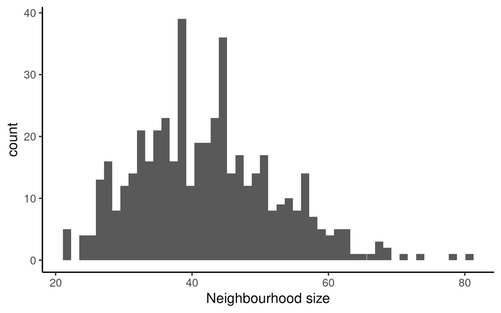

```r
# Check neighborhoods
plotNhoodSizeHist(seurat_obj_milo)
```

```r
ggsave(paste0(proj_name, "_MiloR_NhoodSizeHist_k20.png"), units = "in", width = 5, height = 4, dpi = 300)
```

## Count cells in neighborhoods

Count how many cells from each sample are in each neighborhood. This count matrix will be used for DA testing.

```r
meta.df <- data.frame(SampleID = seurat_obj_milo@colData$mouse,
                      Condition = seurat_obj_milo@colData$group)
seurat_obj_milo_count <- countCells(seurat_obj_milo, meta.data = meta.df, sample="SampleID")
```

```
## Checking meta.data validity
```

```
## Counting cells in neighbourhoods
```

```r
head(nhoodCounts(seurat_obj_milo_count))
```

```
## 6 x 4 sparse Matrix of class "dgCMatrix"
##   WT-1 WT-2 375KO-1 375KO-2
## 1   10    6       7      15
## 2   25    1      19       4
## 3    4    6      37       8
## 4   10    7      19       7
## 5   10   11      13      18
## 6    5    3      13       7
```

## Differential Abundence test

DA test is based on Negative Binomial GLM implementation in `edgeR`. For computting neighborhood connectivity, Milo uses an adaptation of the Spatial FDR correction introduced by `cydar`. *Note*: Since my dataset is small, nothing really came out as significant.

```r
# Make design matrix
milo_design <- meta.df[,c("SampleID", "Condition")]
milo_design <- distinct(milo_design)
milo_design
```

```
##   SampleID Condition
## 1     WT-1        WT
## 2     WT-2        WT
## 3  375KO-1     375KO
## 4  375KO-2     375KO
```

```r
# Design matrix matches samples to a condition of interest.
rownames(milo_design) <- milo_design$SampleID

# Compute neighbourhood connectivity
dat_milo <- calcNhoodDistance(seurat_obj_milo_count, d=30)

# Perform DA analysis
dat_results <- testNhoods(dat_milo, design = ~ Condition, design.df = milo_design)

# Check DA result
dat_results %>%
  arrange(SpatialFDR) %>%
  head()
```

```
##        logFC   logCPM          F     PValue       FDR Nhood SpatialFDR
## 1 -0.4678827 11.19356 0.42449709 0.53590299 0.9970462     1  0.9956967
## 2  0.2335014 11.35897 0.04148396 0.84626329 0.9970462     2  0.9956967
## 3 -1.8887174 11.52576 6.32009394 0.04081635 0.9970462     3  0.9956967
## 4 -0.4447856 11.26664 0.60186682 0.46375924 0.9970462     4  0.9956967
## 5 -0.4845179 11.58112 0.68739315 0.43493926 0.9970462     5  0.9956967
## 6 -1.1782223 10.77296 3.38370583 0.10927615 0.9970462     6  0.9956967
```

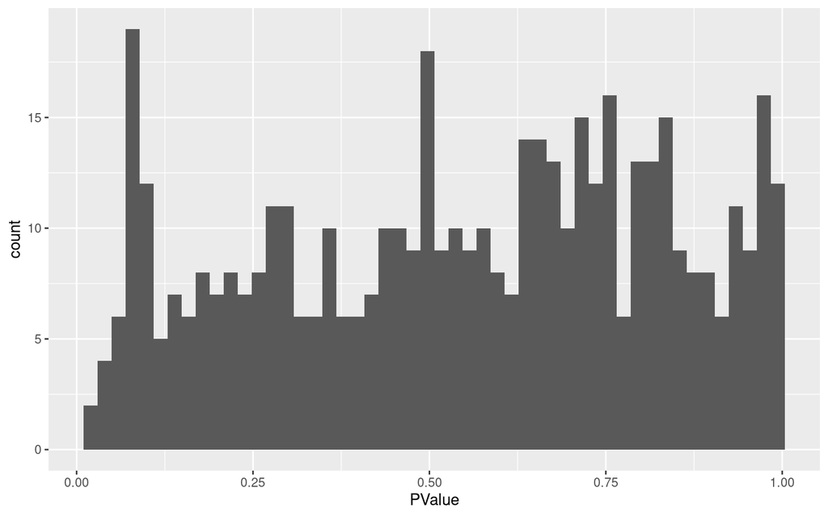

```r
# QC plots
ggplot(dat_results, aes(PValue)) + geom_histogram(bins=50)
```

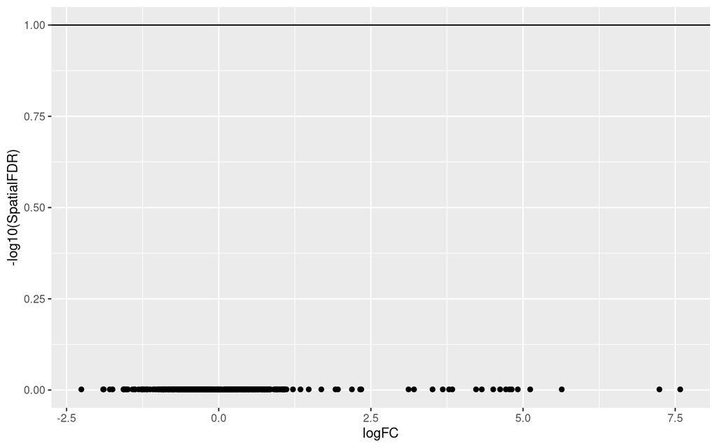

```r
ggplot(dat_results, aes(logFC, -log10(SpatialFDR))) +
  geom_point() +
  geom_hline(yintercept = 1) ## Mark significance threshold (10% FDR)
```

## Visualization

*Note*: since there’s no significant DA in my dataset, I also ploted using FDR threshold > 0.999 to show fold change difference between WT and KO.

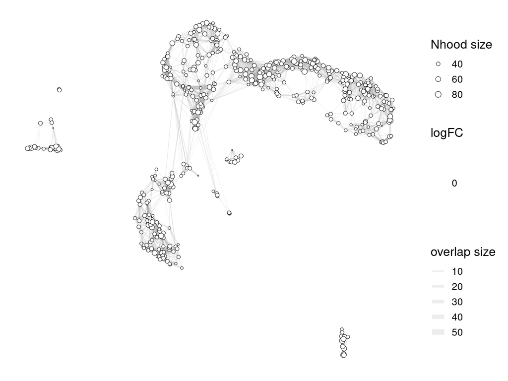

```r
dat_milo <- buildNhoodGraph(dat_milo)

plotNhoodGraphDA(dat_milo, dat_results, alpha = 0.05)
```

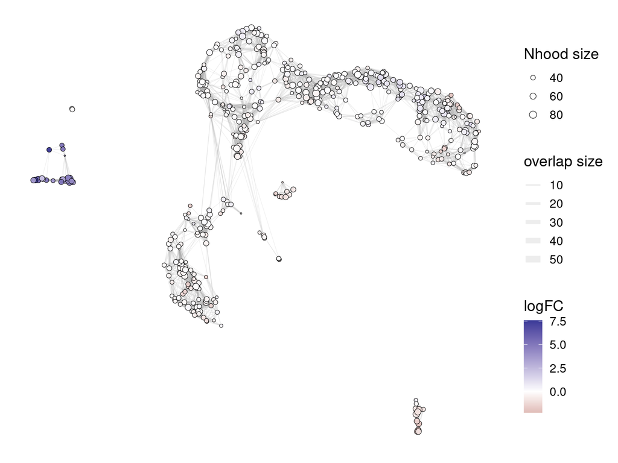

```r
ggsave(paste0(proj_name, "_MiloR_k20_plotNhoodGraphDA_FDR0.05_test.png"))

plotNhoodGraphDA(dat_milo, dat_results, alpha = 0.999)
```

```r
ggsave(paste0(proj_name, "_MiloR_k20_plotNhoodGraphDA_FDR0.999_test.png"))
```